# NYPD

2023-09-02

# Data Source

This data was sourced from https://catalog.data.gov/dataset. This dataset is published and maintained by the city of New York.  
The data contains information on the victim and purpertators demographic information, the location, date, and time of the crime, and a category describing the crime. Using this information, we can evaluate the patterns found in the demographic information that is available.

```r
library(tidyverse)
```

```r
RawData <- read_csv("./data/NYPD_Shooting_Incident_Data__Historic_.csv")
```

# Tidy and Transform

```r
Data <- RawData %>% mutate(OCCUR_DATE = mdy(OCCUR_DATE))
Data <- subset(Data,select=-c(Lon_Lat,X_COORD_CD,Y_COORD_CD))
Data$PERP_AGE_GROUP[(Data$PERP_AGE_GROUP == "(null)")] <- NA
Data$PERP_AGE_GROUP[(Data$PERP_AGE_GROUP == 1020)] <- NA
Data$PERP_AGE_GROUP[(Data$PERP_AGE_GROUP == "UNKNOWN")] <- NA
Data$PERP_AGE_GROUP[(Data$PERP_AGE_GROUP == 940)] <- NA
Data$PERP_RACE[(Data$PERP_RACE == "(null)")] <- NA
Data$PERP_RACE[(Data$PERP_RACE == "UNKNOWN")] <- NA
Data$VIC_AGE_GROUP[(Data$VIC_AGE_GROUP == "UNKNOWN")] <- NA
Data$VIC_AGE_GROUP[(Data$VIC_AGE_GROUP == 1022)] <- NA
```

# Demographics Of Perpatrator and Victim

Using the provided information, we can identify the most common races and age groups associated with various crimes.

## Perpatrator Demographics

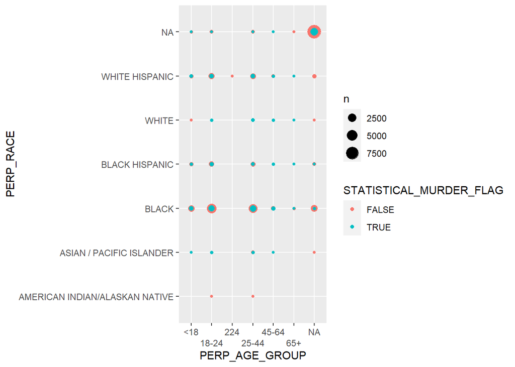

```r
ggplot(Data, aes(y = PERP_RACE, x = PERP_AGE_GROUP, color = STATISTICAL_MURDER_FLAG)) + geom_count()+guides(x = guide_axis(n.dodge = 2))
```

## Victim Demographics

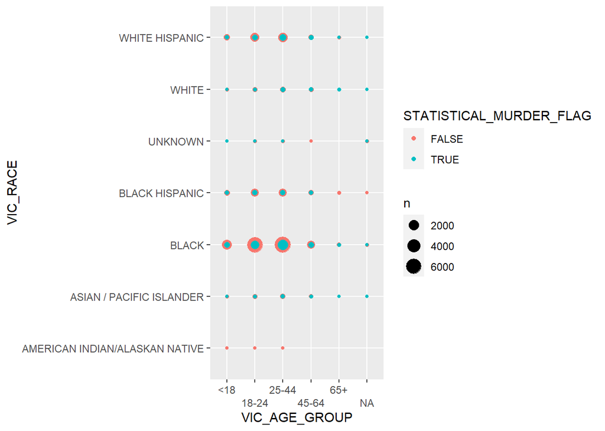

```r
ggplot(Data, aes(y = VIC_RACE, x = VIC_AGE_GROUP, color = STATISTICAL_MURDER_FLAG)) + geom_count()+guides(x = guide_axis(n.dodge = 2))
```

## Murder Victim Race by Location

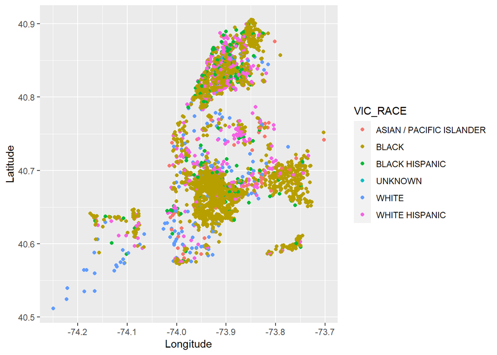

```r
ggplot(filter(Data, STATISTICAL_MURDER_FLAG == TRUE), aes(x=Longitude, y=Latitude, color = VIC_RACE))+geom_point()
```

When mapping out the locations of the murders by victims race, we can see that the distribution of murders have some fairly dense areas, but shows a lot of diversity across the map.

# Biases

Looking at the map and the victim demographic information. It becomes clear that there are certain groups that receive more hostility and are treated more violently. I was expecting the races to be much more concentrated in the city. It was shown there was diversity across the city when it comes to being a murder victim.